# Filter variants by predicted effect, wecare sep2016

Alexey Larionov

started: 01Mar2016  
last updated: 22Dec2016

# Criteria

### Loss of function

“splice_acceptor_variant”, “splice_donor_variant”, “stop_gain”, “stop_lost”, “start_lost”, “frameshift_variant” : 5,152 variants

### Missense

“deleterious” and “probably_damaging”: 18,350 variants (dd) or “deleterious” and (“probably_damaging” or “possibly_damaging”): 27,754 variants (ddd)

### ClinSig

“likely_pathogenic”, “risk_factor”, “pathogenic”, “association”, “protective”, “drug_response”: 793 variants

### High AF in 1k (i.e. rare sequence versions in Ref Genome)

EUR_AF>0.9 : 3,374 variants

### Total retained

**Variants:** 23,923 (33,238 ddd) **Genes:** 10,222 (11,812 ddd) ~2.34 protein-affecting variants per gene (2.81 ddd)

### Not included: “cosm” in Existing_Variation

32,322 variants

# start_section

```r
# Start time
Sys.time()
```

```
## [1] "2016-12-22 12:07:59 GMT"
```

```r
# Do NOT clean-up at this stage
#rm(list=ls()) # this would remove params object!
graphics.off()

# Read parameters
interim_data_folder <- params$interim_data

# Load libraries
library(dplyr)
library(reshape2) # for melt()
library(ggplot2)

# Set root working folder
#library(knitr)
#opts_knit$set(root.dir = "/scratch/medgen/scripts/wecare_stat_11.16/scripts")
#setwd("/scratch/medgen/scripts/wecare_stat_11.16/scripts")
```

# load_data

```r
# Remove params object to avoid interference with load() function
rm(params)

# Load data
load(paste(interim_data_folder, "s03_update_phenotypes.RData", sep="/"))
```

# check_data

```r
ls()
```

```
## [1] "exac.df"                 "gt_nfe.mx"
## [3] "gt_wecare_pf.mx"         "interim_data_folder"
## [5] "kgen.df"                 "params"
## [7] "phenotypes_wecare_pf.df" "variants.df"
```

```r
dim(gt_wecare_pf.mx)
```

```
## [1] 279874    491
```

```r
class(gt_wecare_pf.mx)
```

```
## [1] "matrix"
```

```r
gt_wecare_pf.mx[1:5,1:5]
```

```
##              P1_A01 P1_A02 P1_A03 P1_A04 P1_A05
## Var000000002      0      0      0      0      0
## Var000000008      0      0     NA      0     NA
## Var000000009      0     NA     NA      0     NA
## Var000000012      0     NA     NA      0      0
## Var000000013      0     NA      0      0      0
```

```r
dim(gt_nfe.mx)
```

```
## [1] 279874    198
```

```r
class(gt_nfe.mx)
```

```
## [1] "matrix"
```

```r
gt_nfe.mx[1:5,1:5]
```

```
##              HG00097 HG00099 HG00100 HG00102 HG00106
## Var000000002       0       0      NA      NA       0
## Var000000008       0      NA       0       0       0
## Var000000009       0       0       0       0       0
## Var000000012       0       0      NA       0       0
## Var000000013       0       0      NA       0       0
```

```r
dim(phenotypes_wecare_pf.df)
```

```
## [1] 491  28
```

```r
str(phenotypes_wecare_pf.df)
```

```
## 'data.frame':    491 obs. of  28 variables:
##  $ wes_id        : chr  "P1_A01" "P1_A02" "P1_A03" "P1_A04" ...
##  $ gwas_id       : chr  "id203568" "id357807" "id325472" "id304354" ...
##  $ merged_id     : chr  "P1_A01_id203568" "P1_A02_id357807" "P1_A03_id325472" "P1_A04_id304354" ...
##  $ filter        : chr  "pass" "pass" "pass" "pass" ...
##  $ cc            : int  1 1 1 1 1 1 0 1 1 1 ...
##  $ setno         : int  203568 357807 325472 304354 222648 244843 276284 297810 310692 250898 ...
##  $ family_history: int  1 0 1 1 1 1 1 1 0 1 ...
##  $ age_dx        : int  49 35 32 33 44 28 28 38 32 35 ...
##  $ age_ref       : num  58 36 41 34 49 28 32 44 39 35 ...
##  $ rstime        : num  10.17 1.83 9.75 1.59 5.66 ...
##  $ eig1_gwas     : num  -0.00389 -0.00379 -0.01011 -0.01288 -0.01086 ...
##  $ eig2_gwas     : num  0.00266 0.00246 -0.0001 0.00595 0.01157 ...
##  $ eig3_gwas     : num  0.06803 0.05055 -0.00603 0.00747 0.00144 ...
##  $ stage         : num  1 2 2 1 1 1 2 1 1 2 ...
##  $ er            : num  NA 0 0 0 NA 1 1 1 0 1 ...
##  $ pr            : num  NA 0 0 NA NA 1 NA 1 0 0 ...
##  $ hist_cat      : chr  "lobular" "ductal" "medullary" "ductal" ...
##  $ hormone       : num  0 0 0 0 1 0 0 0 0 0 ...
##  $ chemo_cat     : chr  "no" "CMF" "Oth" "no" ...
##  $ br_xray       : int  1 1 0 0 1 0 0 0 0 1 ...
##  $ br_xray_dose  : num  1.6 0.83 0 0 0.77 0 0 0 0 1.1 ...
##  $ age_menarche  : num  9 13 10 12 10 13 12 11 12 11 ...
##  $ age_1st_ftp   : num  30 0 26 0 17 0 25 28 21 27 ...
##  $ age_menopause : num  -1 -1 -1 -1 -1 -1 -1 -1 -1 -1 ...
##  $ num_preg      : num  1 0 1 0 1 0 1 1 1 1 ...
##  $ bmi_age18     : num  20.8 22.5 23.6 18.6 19.9 ...
##  $ bmi_dx        : num  25.8 22.9 28.3 17.8 26.6 ...
##  $ bmi_ref       : num  33.3 22.9 33.1 17.8 29.8 ...
```

```r
phenotypes_wecare_pf.df[1:5,1:5]
```

```
##        wes_id  gwas_id       merged_id filter cc
## P1_A01 P1_A01 id203568 P1_A01_id203568   pass  1
## P1_A02 P1_A02 id357807 P1_A02_id357807   pass  1
## P1_A03 P1_A03 id325472 P1_A03_id325472   pass  1
## P1_A04 P1_A04 id304354 P1_A04_id304354   pass  1
## P1_A05 P1_A05 id222648 P1_A05_id222648   pass  1
```

```r
dim(variants.df)
```

```
## [1] 279874     23
```

```r
colnames(variants.df)
```

```
##  [1] "SplitVarID"         "SYMBOL"             "TYPE"
##  [4] "CHROM"              "POS"                "REF"
##  [7] "ALT"                "AC"                 "AF"
## [10] "AN"                 "Consequence"        "SIFT_call"
## [13] "SIFT_score"         "PolyPhen_call"      "PolyPhen_score"
## [16] "CLIN_SIG"           "cDNA_position"      "CDS_position"
## [19] "Codons"             "Protein_position"   "Amino_acids"
## [22] "Existing_variation" "Multiallelic"
```

```r
variants.df[1:5,1:5]
```

```
##                SplitVarID    SYMBOL  TYPE CHROM    POS
## Var000000002 Var000000002 LINC00115   SNP     1 762330
## Var000000008 Var000000008    SAMD11   SNP     1 871215
## Var000000009 Var000000009    SAMD11   SNP     1 871230
## Var000000012 Var000000012    SAMD11 INDEL     1 874778
## Var000000013 Var000000013    SAMD11   SNP     1 878664
```

```r
dim(kgen.df)
```

```
## [1] 279874      9
```

```r
colnames(kgen.df)
```

```
## [1] "SplitVarID"  "kgen.AC"     "kgen.AN"     "kgen.AF"     "kgen.AFR_AF"
## [6] "kgen.AMR_AF" "kgen.EAS_AF" "kgen.EUR_AF" "kgen.SAS_AF"
```

```r
kgen.df[1:5,1:5]
```

```
##                SplitVarID kgen.AC kgen.AN     kgen.AF kgen.AFR_AF
## Var000000002 Var000000002      NA      NA          NA          NA
## Var000000008 Var000000008      NA      NA          NA          NA
## Var000000009 Var000000009      NA      NA          NA          NA
## Var000000012 Var000000012      NA      NA          NA          NA
## Var000000013 Var000000013       2    5008 0.000399361           0
```

```r
dim(exac.df)
```

```
## [1] 279874     48
```

```r
colnames(exac.df)
```

```
##  [1] "SplitVarID"              "exac_non_TCGA.AF"
##  [3] "exac_non_TCGA.AC"        "exac_non_TCGA.AN"
##  [5] "exac_non_TCGA.AC_FEMALE" "exac_non_TCGA.AN_FEMALE"
##  [7] "exac_non_TCGA.AC_MALE"   "exac_non_TCGA.AN_MALE"
##  [9] "exac_non_TCGA.AC_Adj"    "exac_non_TCGA.AN_Adj"
## [11] "exac_non_TCGA.AC_Hom"    "exac_non_TCGA.AC_Het"
## [13] "exac_non_TCGA.AC_Hemi"   "exac_non_TCGA.AC_AFR"
## [15] "exac_non_TCGA.AN_AFR"    "exac_non_TCGA.Hom_AFR"
## [17] "exac_non_TCGA.Het_AFR"   "exac_non_TCGA.Hemi_AFR"
## [19] "exac_non_TCGA.AC_AMR"    "exac_non_TCGA.AN_AMR"
## [21] "exac_non_TCGA.Hom_AMR"   "exac_non_TCGA.Het_AMR"
## [23] "exac_non_TCGA.Hemi_AMR"  "exac_non_TCGA.AC_EAS"
## [25] "exac_non_TCGA.AN_EAS"    "exac_non_TCGA.Hom_EAS"
## [27] "exac_non_TCGA.Het_EAS"   "exac_non_TCGA.Hemi_EAS"
## [29] "exac_non_TCGA.AC_FIN"    "exac_non_TCGA.AN_FIN"
## [31] "exac_non_TCGA.Hom_FIN"   "exac_non_TCGA.Het_FIN"
## [33] "exac_non_TCGA.Hemi_FIN"  "exac_non_TCGA.AC_NFE"
## [35] "exac_non_TCGA.AN_NFE"    "exac_non_TCGA.Hom_NFE"
## [37] "exac_non_TCGA.Het_NFE"   "exac_non_TCGA.Hemi_NFE"
## [39] "exac_non_TCGA.AC_SAS"    "exac_non_TCGA.AN_SAS"
## [41] "exac_non_TCGA.Hom_SAS"   "exac_non_TCGA.Het_SAS"
## [43] "exac_non_TCGA.Hemi_SAS"  "exac_non_TCGA.AC_OTH"
## [45] "exac_non_TCGA.AN_OTH"    "exac_non_TCGA.Hom_OTH"
## [47] "exac_non_TCGA.Het_OTH"   "exac_non_TCGA.Hemi_OTH"
```

```r
exac.df[1:5,1:5]
```

```
##                SplitVarID exac_non_TCGA.AF exac_non_TCGA.AC
## Var000000002 Var000000002        0.0120000              175
## Var000000008 Var000000008               NA               NA
## Var000000009 Var000000009               NA               NA
## Var000000012 Var000000012               NA               NA
## Var000000013 Var000000013        0.0005838               62
##              exac_non_TCGA.AN exac_non_TCGA.AC_FEMALE
## Var000000002            14012                      59
## Var000000008               NA                    1553
## Var000000009               NA                      NA
## Var000000012               NA                      NA
## Var000000013           106198                      17
```

```r
# Check consistency of rownames and colnames
sum(colnames(gt_wecare_pf.mx) != rownames(phenotypes_wecare_pf.df))
```

```
## [1] 0
```

```r
sum(rownames(gt_wecare_pf.mx) != rownames(gt_nfe.mx))
```

```
## [1] 0
```

```r
sum(rownames(gt_wecare_pf.mx) != rownames(variants.df))
```

```
## [1] 0
```

```r
sum(rownames(gt_wecare_pf.mx) != rownames(kgen.df))
```

```
## [1] 0
```

```r
sum(rownames(gt_wecare_pf.mx) != rownames(exac.df))
```

```
## [1] 0
```

```r
# Check consistency of er1/pr1 and endocrine treatment
# (note 2 er/pr-negatives treated with hormones)
phenotypes_wecare_pf.df %>%
  filter(er==0 & hormone == 1) %>%
  select(wes_id, gwas_id, er, pr, hormone)
```

```
##    wes_id  gwas_id er pr hormone
## 1  P1_G06 id212405  0  1       1
## 2  P1_G11 id367005  0  1       1
## 3  P2_A08 id202026  0  1       1
## 4  P2_C11 id243493  0  1       1
## 5  P2_D05 id248876  0  1       1
## 6  P3_C06 id294079  0  1       1
## 7  P4_D09 id242684  0  1       1
## 8  P4_G04 id272828  0  0       1
## 9  P5_D10 id357932  0  0       1
## 10 P6_C01 id256943  0  1       1
## 11 P6_C09 id297183  0  1       1
```

# explore_variants_annotations

```r
# SIFT
unique(as.vector(variants.df$SIFT_call))
```

```
## [1] NA                           "tolerated"
## [3] "deleterious"                "deleterious_low_confidence"
## [5] "tolerated_low_confidence"
```

```r
# PolyPhen
unique(as.vector(variants.df$PolyPhen_call))
```

```
## [1] NA                  "benign"            "probably_damaging"
## [4] "possibly_damaging" "unknown"
```

```r
#CLIN_SIG
unique(unlist(strsplit(as.vector(variants.df$CLIN_SIG), split="\\&")))
```

```
##  [1] NA                       "likely_benign"
##  [3] "benign"                 "likely_pathogenic"
##  [5] "risk_factor"            "not_provided"
##  [7] "uncertain_significance" "pathogenic"
##  [9] "association"            "protective"
## [11] "other"                  "drug_response"
```

# explore_variants_frequent_in_kgen_and_exac

These are rare sequence versions slipped into reference genome (b37)

```r
x <- kgen.df  %>% filter(kgen.EUR_AF > 0.9) %>% select(SplitVarID) # 3,374
y <- exac.df  %>% filter(exac_non_TCGA.AF > 0.9) %>% select(SplitVarID) # 2,613

x <- as.character(x[,1])
y <- as.character(y[,1])
z <- intersect(x,y) # 2,461

length(x)
```

```
## [1] 3374
```

```r
length(y)
```

```
## [1] 2613
```

```r
length(z)
```

```
## [1] 2461
```

```r
rm(x,y,z)
```

# Notes

### Annotations seen in Wecare and NFE

*SIFT:* “tolerated”, “deleterious”, “tolerated_low_confidence”, “deleterious_low_confidence”  
*PolyPhen:* “benign”, “possibly_damaging”, “probably_damaging”, “unknown”  
*CLIN_SIG:* “likely_benign”, “benign”, “likely_pathogenic”, “risk_factor”, “not_provided”, “uncertain_significance”, “pathogenic”, “association”, “protective”, “other”, “drug_response”  
I have also seen “confers_sensitivity” in CLIN_SIG for gastric cases *Somatic:* COSM in Existing_variation

### Interpreting SIFT and PolyPhen scores (not used here)

*SIFT:* the higher score the less deleterious  
*PolyPhen:* the higher score the more damaging

### Rare sequence versions in Ref genome

There are ~2-3k of sites, which are anomaliously frequent (AF>0.9) in kgen and exac.

They should be rempoved because “variants” called in these sites represent sequence versions common in humans, despite the misleading “low” MAFs in some databases.

# make_lof_index

```r
# --- Splice acceptor variants --- #

splice_acceptor_variant <- grepl( "splice_acceptor_variant", variants.df$Consequence)
sum(splice_acceptor_variant) # 438
```

```
## [1] 438
```

```r
# mean count of alleles per case in nfe
sav_nfe.mx <- gt_nfe.mx[splice_acceptor_variant,]
sav_nfe.counts <- apply(sav_nfe.mx, 2, sum, na.rm=TRUE)
sav_nfe.mean <- mean(sav_nfe.counts, na.rm=TRUE) # ~24
rm(sav_nfe.mx, sav_nfe.counts)

# mean count of alleles per case in wecare
sav_wecare_pf.mx <- gt_wecare_pf.mx[splice_acceptor_variant,]
sav_wecare_pf.counts <- apply(sav_wecare_pf.mx, 2, sum, na.rm=TRUE)
sav_wecare_pf.mean <- mean(sav_wecare_pf.counts, na.rm=TRUE) # ~31
rm(sav_wecare_pf.mx, sav_wecare_pf.counts)

# --- Splice donor variants --- #

splice_donor_variant <- grepl( "splice_donor_variant", variants.df$Consequence)
sum(splice_donor_variant) # 638
```

```
## [1] 638
```

```r
# mean count of alleles per case in nfe
sdv_nfe.mx <- gt_nfe.mx[splice_donor_variant,]
sdv_nfe.counts <- apply(sdv_nfe.mx, 2, sum, na.rm=TRUE)
sdv_nfe.mean <- mean(sdv_nfe.counts, na.rm=TRUE) # ~16
rm(sdv_nfe.mx, sdv_nfe.counts)

# mean count of alleles per case in wecare
sdv_wecare_pf.mx <- gt_wecare_pf.mx[splice_donor_variant,]
sdv_wecare_pf.counts <- apply(sdv_wecare_pf.mx, 2, sum, na.rm=TRUE)
sdv_wecare_pf.mean <- mean(sdv_wecare_pf.counts, na.rm=TRUE) # ~17
rm(sdv_wecare_pf.mx, sdv_wecare_pf.counts)

# --- Stop gains --- #

stop_gain <- grepl( "stop_gain", variants.df$Consequence)
sum(stop_gain) # 2240
```

```
## [1] 2240
```

```r
# mean count of alleles per case in nfe
stogv_nfe.mx <- gt_nfe.mx[stop_gain,]
stogv_nfe.counts <- apply(stogv_nfe.mx, 2, sum, na.rm=TRUE)
stogv_nfe.mean <- mean(stogv_nfe.counts, na.rm=TRUE) # ~47
rm(stogv_nfe.mx, stogv_nfe.counts)

# mean count of alleles per case in wecare
stogv_wecare_pf.mx <- gt_wecare_pf.mx[stop_gain,]
stogv_wecare_pf.counts <- apply(stogv_wecare_pf.mx, 2, sum, na.rm=TRUE)
stogv_wecare_pf.mean <- mean(stogv_wecare_pf.counts, na.rm=TRUE) # ~51
rm(stogv_wecare_pf.mx, stogv_wecare_pf.counts)

# --- Stop losts --- #

stop_lost <- grepl( "stop_lost", variants.df$Consequence)
sum(stop_lost) # 80
```

```
## [1] 80
```

```r
# mean count of alleles per case in nfe
stolv_nfe.mx <- gt_nfe.mx[stop_lost,]
stolv_nfe.counts <- apply(stolv_nfe.mx, 2, sum, na.rm=TRUE)
stolv_nfe.mean <- mean(stolv_nfe.counts, na.rm=TRUE) # ~13
rm(stolv_nfe.mx, stolv_nfe.counts)

# mean count of alleles per case in wecare
stolv_wecare_pf.mx <- gt_wecare_pf.mx[stop_lost,]
stolv_wecare_pf.counts <- apply(stolv_wecare_pf.mx, 2, sum, na.rm=TRUE)
stolv_wecare_pf.mean <- mean(stolv_wecare_pf.counts, na.rm=TRUE) # ~16
rm(stolv_wecare_pf.mx, stolv_wecare_pf.counts)

# Interestingly, there are much less of stop_losts than stop_gains: 81 and 2277 respectively
# This looks contraintuitive, suggesting that stop_losses may be under stronger evolutionary
# control than stop_gains??

# --- Start losts --- #
# Functional significance of start losses may be questioned. However, their
# total number is small, so they should not influence the analysis too much in any case.
# Could there be such thing as "Start gain" ?

start_lost <- grepl( "start_lost", variants.df$Consequence)
sum(start_lost) # 147
```

```
## [1] 147
```

```r
# mean count of alleles per case in nfe
stalv_nfe.mx <- gt_nfe.mx[start_lost,]
stalv_nfe.counts <- apply(stalv_nfe.mx, 2, sum, na.rm=TRUE)
stalv_nfe.mean <- mean(stalv_nfe.counts, na.rm=TRUE) # ~6
rm(stalv_nfe.mx, stalv_nfe.counts)

# mean count of alleles per case in wecare
stalv_wecare_pf.mx <- gt_wecare_pf.mx[start_lost,]
stalv_wecare_pf.counts <- apply(stalv_wecare_pf.mx, 2, sum, na.rm=TRUE)
stalv_wecare_pf.mean <- mean(stalv_wecare_pf.counts, na.rm=TRUE) # ~8
rm(stalv_wecare_pf.mx, stalv_wecare_pf.counts)

# --- Frameshifts --- #

frameshift_variant <- grepl( "frameshift_variant", variants.df$Consequence)
sum(frameshift_variant) # 1660
```

```
## [1] 1660
```

```r
# mean count of alleles per case in nfe
fsv_nfe.mx <- gt_nfe.mx[frameshift_variant,]
fsv_nfe.counts <- apply(fsv_nfe.mx, 2, sum, na.rm=TRUE)
fsv_nfe.mean <- mean(fsv_nfe.counts, na.rm=TRUE) # ~137
rm(fsv_nfe.mx, fsv_nfe.counts)

# mean count of alleles per case in wecare
fsv_wecare_pf.mx <- gt_wecare_pf.mx[frameshift_variant,]
fsv_wecare_pf.counts <- apply(fsv_wecare_pf.mx, 2, sum, na.rm=TRUE)
fsv_wecare_pf.mean <- mean(fsv_wecare_pf.counts, na.rm=TRUE) # ~162
rm(fsv_wecare_pf.mx, fsv_wecare_pf.counts)

# --- all LoF-s --- #

lof_all <- splice_acceptor_variant | splice_donor_variant | stop_gain | stop_lost | start_lost | frameshift_variant

sum(lof_all) # 5,152
```

```
## [1] 5152
```

```r
# mean count of alleles per case in nfe
lof_nfe.mx <- gt_nfe.mx[lof_all,]
lof_nfe.counts <- apply(lof_nfe.mx, 2, sum, na.rm=TRUE)
lof_nfe.mean <- mean(lof_nfe.counts, na.rm=TRUE) # ~238
rm(lof_nfe.mx, lof_nfe.counts)

# mean count of alleles per case in wecare
lof_wecare_pf.mx <- gt_wecare_pf.mx[lof_all,]
lof_wecare_pf.counts <- apply(lof_wecare_pf.mx, 2, sum, na.rm=TRUE)
lof_wecare_pf.mean <- mean(lof_wecare_pf.counts, na.rm=TRUE) # ~279
rm(lof_wecare_pf.mx, lof_wecare_pf.counts)

# Clean-up
rm(splice_acceptor_variant, splice_donor_variant, stop_gain, frameshift_variant, stop_lost, start_lost)
```

# compare_lofs_in_nfs_and_wecare_pf

```r
# Summary table with LoFs per individual in nfe and wecare_pf
lof_nfe_summary_counts <- c(sav_nfe.mean, sdv_nfe.mean, stogv_nfe.mean,
            stolv_nfe.mean, stalv_nfe.mean, fsv_nfe.mean, lof_nfe.mean)

lof_wecare_pf_summary_counts <- c(sav_wecare_pf.mean, sdv_wecare_pf.mean,
        stogv_wecare_pf.mean, stolv_wecare_pf.mean, stalv_wecare_pf.mean,
        fsv_wecare_pf.mean, lof_wecare_pf.mean)

lof_summary_counts <- rbind(lof_wecare_pf_summary_counts, lof_nfe_summary_counts)
rownames(lof_summary_counts) <- c("wecare_pf", "nfe")
colnames(lof_summary_counts) <- c("splice_acceptor", "splice_donior", "stop_gain",
                              "stop_lost", "start_lost", "frameshift", "all_LoFs")

lof_summary_counts
```

```
##           splice_acceptor splice_donior stop_gain stop_lost start_lost
## wecare_pf        31.17923      16.66191  50.70672  15.71690   8.346232
## nfe              23.86869      16.00505  47.31313  12.75758   5.914141
##           frameshift all_LoFs
## wecare_pf   162.0876 278.9450
## nfe         136.7677 238.0657
```

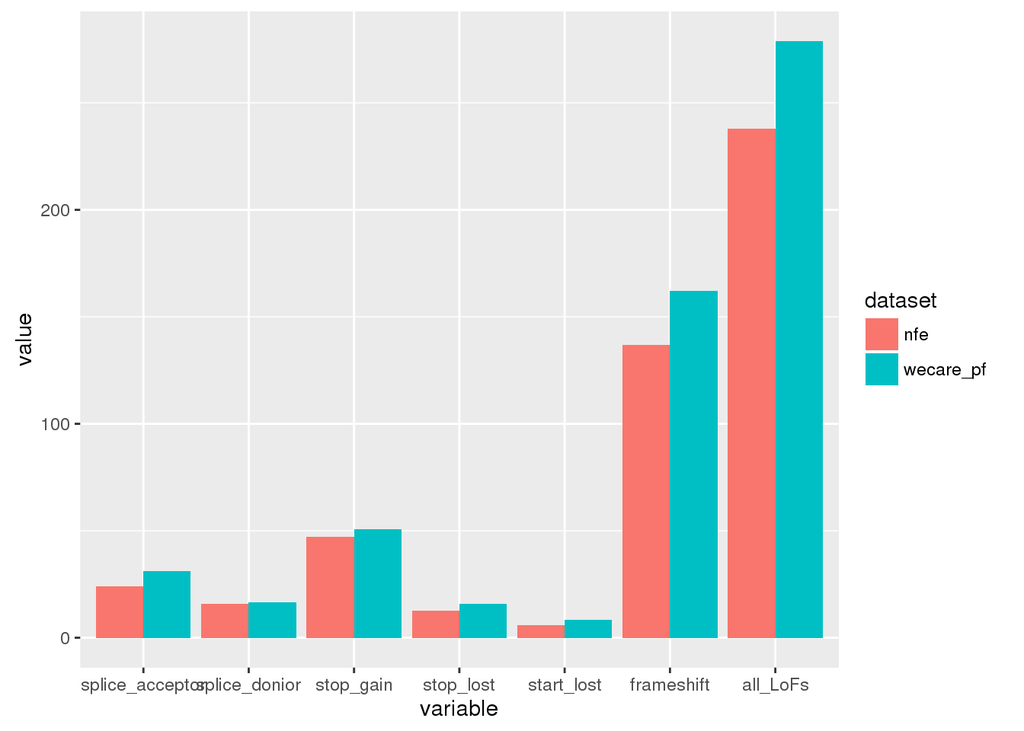

```r
# Summary plot with LoFs per individual in nfe and wecare_pf
lof_summary_counts.df <- as.data.frame(lof_summary_counts)
lof_summary_counts.df <- cbind(rownames(lof_summary_counts.df), lof_summary_counts.df)
colnames(lof_summary_counts.df)[1] <- "dataset"

lof_summary_counts.m <- melt(lof_summary_counts.df, id.vars="dataset")
ggplot(lof_summary_counts.m, aes(variable, value)) +
  geom_bar(aes(fill = dataset), position = "dodge", stat="identity")
```

```r
# Clean-up
rm(sav_nfe.mean, sdv_nfe.mean, stogv_nfe.mean, stolv_nfe.mean, stalv_nfe.mean, fsv_nfe.mean,
   sav_wecare_pf.mean, sdv_wecare_pf.mean, stogv_wecare_pf.mean, stolv_wecare_pf.mean, stalv_wecare_pf.mean,
   fsv_wecare_pf.mean, lof_nfe_summary_counts, lof_wecare_pf_summary_counts,
   lof_summary_counts, lof_summary_counts.df, lof_summary_counts.m)
```

# make_missense_index

```r
missense_all <- grepl( "missense_variant", variants.df$Consequence)
sum(missense_all) # 109,219
```

```
## [1] 109219
```

```r
deleterious <- variants.df$SIFT_call == "deleterious"
FALSE -> deleterious[is.na(deleterious)]
sum(deleterious) # 38,350
```

```
## [1] 38350
```

```r
probably_damaging <- variants.df$PolyPhen_call == "probably_damaging"
FALSE -> probably_damaging[is.na(probably_damaging)]
sum(probably_damaging) # 25,007
```

```
## [1] 25007
```

```r
missense_dd <- deleterious & probably_damaging
sum(missense_dd) # 18,350
```

```
## [1] 18350
```

```r
# mean count of missense-dd alleles per case in nfe
missense_dd_nfe.mx <- gt_nfe.mx[missense_dd,]
missense_dd_nfe.counts <- apply(missense_dd_nfe.mx, 2, sum, na.rm=TRUE)
missense_dd_nfe.mean <- mean(missense_dd_nfe.counts, na.rm=TRUE)
missense_dd_nfe.mean # ~367
```

```
## [1] 366.596
```

```r
rm(missense_dd_nfe.mx, missense_dd_nfe.counts)

# mean count of missense-dd alleles per case in wecare
missense_dd_wecare_pf.mx <- gt_wecare_pf.mx[missense_dd,]
missense_dd_wecare_pf.counts <- apply(missense_dd_wecare_pf.mx, 2, sum, na.rm=TRUE)
missense_dd_wecare_pf.mean <- mean(missense_dd_wecare_pf.counts, na.rm=TRUE)
missense_dd_wecare_pf.mean # ~380
```

```
## [1] 380.3707
```

```r
rm(missense_dd_wecare_pf.mx, missense_dd_wecare_pf.counts)

# Clean-up
rm(missense_all, deleterious, probably_damaging)
```

# make_clinsig_index

ClinSig version as reported by VEP of Ensembl v83 (Jan2016) ClinVar is a better variant that may be used in future. Note sums w/o na.rm=TRUE.

```r
clinsig_terms <- c("likely_pathogenic", "risk_factor", "pathogenic", "association", "protective", "drug_response")

clinsig <- variants.df$CLIN_SIG %in% clinsig_terms
sum(clinsig) # 793
```

```
## [1] 793
```

```r
# mean count of alleles per case in nfe
clinsig_nfe.mx <- gt_nfe.mx[clinsig,]
clinsig_nfe.counts <- apply(clinsig_nfe.mx, 2, sum, na.rm=TRUE)
clinsig_nfe.mean <- mean(clinsig_nfe.counts, na.rm=TRUE)
clinsig_nfe.mean # ~89
```

```
## [1] 88.78283
```

```r
rm(clinsig_nfe.mx, clinsig_nfe.counts)

# mean count of alleles per case in wecare
clinsig_wecare_pf.mx <- gt_wecare_pf.mx[clinsig,]
clinsig_wecare_pf.counts <- apply(clinsig_wecare_pf.mx, 2, sum, na.rm=TRUE)
clinsig_wecare_pf.mean <- mean(clinsig_wecare_pf.counts, na.rm=TRUE)
clinsig_wecare_pf.mean # 90
```

```
## [1] 89.58859
```

```r
rm(clinsig_wecare_pf.mx, clinsig_wecare_pf.counts)

rm(clinsig_terms)
```

# make_frequent_in_kgen_index

```r
kgen_frequent <- kgen.df$kgen.EUR_AF > 0.9
FALSE -> kgen_frequent[is.na(kgen_frequent)]
sum(kgen_frequent) # 3,374
```

```
## [1] 3374
```

```r
# mean count of alleles per case in nfe
kgen_nfe.mx <- gt_nfe.mx[kgen_frequent,]
kgen_nfe.counts <- apply(kgen_nfe.mx, 2, sum, na.rm=TRUE)
kgen_nfe.mean <- mean(kgen_nfe.counts, na.rm=TRUE)
kgen_nfe.mean # ~5788
```

```
## [1] 5788.061
```

```r
rm(kgen_nfe.mx, kgen_nfe.counts)

# mean count of alleles per case in wecare
kgen_wecare_pf.mx <- gt_wecare_pf.mx[kgen_frequent,]
kgen_wecare_pf.counts <- apply(kgen_wecare_pf.mx, 2, sum, na.rm=TRUE)
kgen_wecare_pf.mean <- mean(kgen_wecare_pf.counts, na.rm=TRUE)
kgen_wecare_pf.mean # ~6362
```

```
## [1] 6362.24
```

```r
rm(kgen_wecare_pf.mx, kgen_wecare_pf.counts)

rm(kgen_nfe.mean, kgen_wecare_pf.mean)
```

# make_cumulative_index

```r
protein_affecting_variants <- ( lof_all | missense_dd | clinsig ) & ( !kgen_frequent )
sum(protein_affecting_variants) # 23,923
```

```
## [1] 23923
```

```r
sum(is.na(protein_affecting_variants)) # 0
```

```
## [1] 0
```

```r
# mean count of alleles per case in nfe
all_vars_nfe.mx <- gt_nfe.mx[protein_affecting_variants,]
all_vars_nfe.counts <- apply(all_vars_nfe.mx, 2, sum, na.rm=TRUE)
all_vars_nfe.mean <- mean(all_vars_nfe.counts, na.rm=TRUE)
all_vars_nfe.mean # ~615
```

```
## [1] 615.0303
```

```r
rm(all_vars_nfe.mx, all_vars_nfe.counts)

# mean count of alleles per case in wecare
all_vars_wecare_pf.mx <- gt_wecare_pf.mx[protein_affecting_variants,]
all_vars_wecare_pf.counts <- apply(all_vars_wecare_pf.mx, 2, sum, na.rm=TRUE)
all_vars_wecare_pf.mean <- mean(all_vars_wecare_pf.counts, na.rm=TRUE)
all_vars_wecare_pf.mean # ~650
```

```
## [1] 649.8635
```

```r
rm(all_vars_wecare_pf.mx, all_vars_wecare_pf.counts)

# Clean-up
rm(lof_all, missense_dd, clinsig, kgen_frequent)
```

# make_somatic_index

Not used for variants selection. Just to have an idea about number of variants annotated in Cosmic

```r
somatic <- grepl("COSM", variants.df$Existing_variation)
sum(somatic) # 32,322
```

```
## [1] 32322
```

```r
rm(somatic)
```

# subset_data

```r
variants.df <- variants.df[protein_affecting_variants,]
kgen.df <- kgen.df[protein_affecting_variants,]
exac.df <- exac.df[protein_affecting_variants,]
gt_nfe.mx <- gt_nfe.mx[protein_affecting_variants,]
gt_wecare_pf.mx <- gt_wecare_pf.mx[protein_affecting_variants,]

# Clean-up
rm(protein_affecting_variants)
```

# compare_variants_counts_in_nfs_and_wecare_pf

```r
# Summary table with LoFs per individual in nfe and wecare_pf
all_nfe_summary_counts <- c(lof_nfe.mean, missense_dd_nfe.mean, clinsig_nfe.mean, all_vars_nfe.mean)
all_wecare_pf_summary_counts <- c(lof_wecare_pf.mean, missense_dd_wecare_pf.mean, clinsig_wecare_pf.mean, all_vars_wecare_pf.mean)

all_summary_counts <- rbind(all_wecare_pf_summary_counts, all_nfe_summary_counts)
rownames(all_summary_counts) <- c("wecare_pf", "nfe")
colnames(all_summary_counts) <- c("lof", "missense_dd", "clinsig", "all")

all_summary_counts
```

```
##                lof missense_dd  clinsig      all
## wecare_pf 278.9450    380.3707 89.58859 649.8635
## nfe       238.0657    366.5960 88.78283 615.0303
```

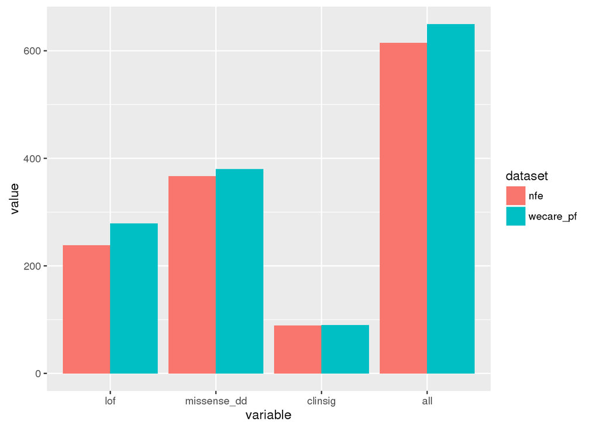

```r
# Summary plot with LoFs per individual in nfe and wecare_pf
all_summary_counts.df <- as.data.frame(all_summary_counts)
all_summary_counts.df <- cbind(rownames(all_summary_counts.df), all_summary_counts.df)
colnames(all_summary_counts.df)[1] <- "dataset"

all_summary_counts.m <- melt(all_summary_counts.df, id.vars="dataset")
ggplot(all_summary_counts.m, aes(variable, value)) +
  geom_bar(aes(fill = dataset), position = "dodge", stat="identity")
```

```r
# Clean-up
rm(missense_dd_nfe.mean, missense_dd_wecare_pf.mean, all_vars_wecare_pf.mean, all_vars_nfe.mean)
```

# num_of_variants_per_gene

```r
length(unique(variants.df$SYMBOL)) # 10,222
```

```
## [1] 10222
```

```r
x <- sort(table(as.vector(variants.df$SYMBOL)), decreasing = TRUE)
x[1:200]
```

```
##
##     DNAH3     DNAH7    MT-CYB   PDE4DIP    PKD1L2     SPTA1     TRPM1
##        36        27        24        23        20        20        19
##       ATM     DUOX2   IGLV3-1   PKHD1L1      CUBN    IGSF10     LAMA1
##        18        18        18        18        17        17        17
##      MUC4    MYO18B     MYOM2     C2CD3    COL6A6   IGKV4-1     LAMA2
##        17        17        17        16        16        16        16
##     MKI67     PKHD1      POLG       TNC     ABCA4     ABCC2     GFRAL
##        15        15        15        15        14        14        14
##      MYH4     MYO1A     MYO7A      NOD2      PLB1      POLQ    PRUNE2
##        14        14        14        14        14        14        14
##      VWA8       XDH      ANK1     CES5A     CSMD3      DYSF     IGHJ5
##        14        14        13        13        13        13        13
##     IGHJ6      LRBA      OCA2        TG     USP45      UTRN     ABCA8
##        13        13        13        13        13        13        12
##     BRCA2     DCHS2        F5       FN1     LAMA4     LAMB2     MYO5C
##        12        12        12        12        12        12        12
##      NID2      SPTB     STAB2   TUBGCP6     UGGT2    UMODL1    ZNF568
##        12        12        12        12        12        12        12
##     A2ML1     AGBL1     ATP7B    CCDC66   COL28A1     DOCK8     ECT2L
##        11        11        11        11        11        11        11
##       EPX    FER1L6       MPO     MYH13     MYOM1      NAV2    NLRP12
##        11        11        11        11        11        11        11
##      NRAP    PDCD11        SI    SPAG17    ABCC11       ACE  ADAMTS14
##        11        11        11        11        10        10        10
##  ADAMTSL1     AMPD1      ASPM   CCDC141      CFTR    DNASE1    DOPEY2
##        10        10        10        10        10        10        10
##     DUOX1    IQGAP2    KCNJ12     KRT36       LPA     MCPH1     MYH15
##        10        10        10        10        10        10        10
##     MYO5B      MYOF     NLRP5     PADI4    PHLPP2    PLA2R1    PTCHD3
##        10        10        10        10        10        10        10
##      ROS1    SCN10A     SCN5A    SLC3A1    SLC5A4      TEP1    ABCA12
##        10        10        10        10        10        10         9
##     ABCB5  ADAMTS12       AGL     ALPK2   ATP13A5        C9   CACNA1S
##         9         9         9         9         9         9         9
##     CAPN9   CCDC136     CD109    CELSR1     CNTLN     CNTN6   CTTNBP2
##         9         9         9         9         9         9         9
##   CYP24A1     DAAM2    DNAH14   EFCAB13      ELP2      EXO1     EXPH5
##         9         9         9         9         9         9         9
##    GPR113     IFIH1     IGHJ4  KIAA0556     LAMC3      MIA3      MLH3
##         9         9         9         9         9         9         9
##     NCOA3    NUP188    NUP205     PALB2      PASK    PCDH15      PCM1
##         9         9         9         9         9         9         9
##      PHKB     POMT1 RAB11FIP1   RAPGEF3    RSPH4A    SCN11A   SLC10A2
##         9         9         9         9         9         9         9
##   SLC22A1     TEX15  TIMELESS      TPTE    UNC45B     UTP20       VWF
##         9         9         9         9         9         9         9
##      WFS1     XIRP1    ZNF106    ZNF268     ABCA3     ABCB6    ABCC12
##         9         9         9         9         8         8         8
##     ACACB   ADAMTS3   ALDH1B1      ANO2    ATP8B3     BRCA1    CABIN1
##         8         8         8         8         8         8         8
##     CASC5   CCDC108   CCDC135    CCHCR1      CCR5     CD101   CD163L1
##         8         8         8         8         8         8         8
##      CD36     CDH23    CELSR2    CEP192     CHEK2    CLTCL1   COL15A1
##         8         8         8         8         8         8         8
##       CR2     DNHD1      DPYD     EEF2K    EGFLAM    EIF4G1     FANCM
##         8         8         8         8         8         8         8
##     FARP2      FBN3      FLNC    FRMPD1
##         8         8         8         8
```

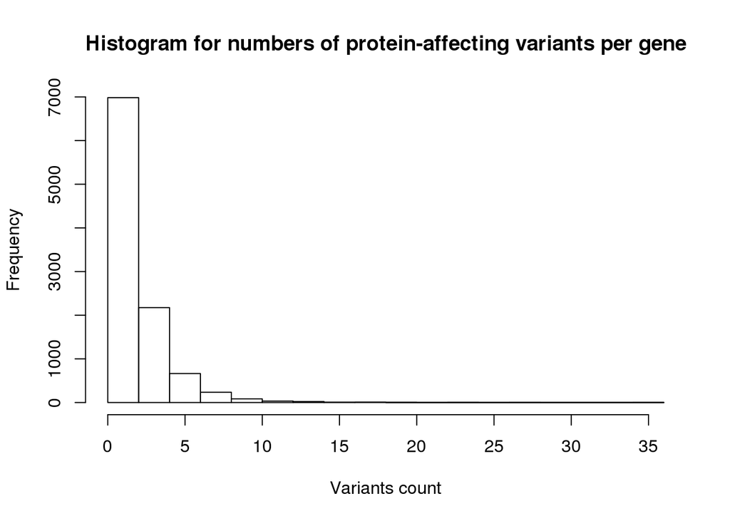

```r
y <- variants.df %>%  group_by(SYMBOL) %>% summarise(n())
"vars_count" -> colnames(y)[2]
hist(y$vars_count, main="Histogram for numbers of protein-affecting variants per gene", xlab="Variants count")
```

```r
mean(y$vars_count) # 2.34
```

```
## [1] 2.340344
```

```r
# Clean-up
rm(x,y)
```

# data_summary

```r
dim(gt_wecare_pf.mx)
```

```
## [1] 23923   491
```

```r
class(gt_wecare_pf.mx)
```

```
## [1] "matrix"
```

```r
gt_wecare_pf.mx[1:5,1:5]
```

```
##              P1_A01 P1_A02 P1_A03 P1_A04 P1_A05
## Var000000026      0     NA      0      0      0
## Var000000029      0      0      0      0      0
## Var000000031      0      0      0      0      0
## Var000000053      0      0      0      0     NA
## Var000000064      0      0      0      0     NA
```

```r
dim(gt_nfe.mx)
```

```
## [1] 23923   198
```

```r
class(gt_nfe.mx)
```

```
## [1] "matrix"
```

```r
gt_nfe.mx[1:5,1:5]
```

```
##              HG00097 HG00099 HG00100 HG00102 HG00106
## Var000000026       0       0       0       0       0
## Var000000029       0       0       0       0       0
## Var000000031       0       0       0       0       0
## Var000000053       0       0       0       0       0
## Var000000064      NA       0       0       0       0
```

```r
dim(kgen.df)
```

```
## [1] 23923     9
```

```r
colnames(kgen.df)
```

```
## [1] "SplitVarID"  "kgen.AC"     "kgen.AN"     "kgen.AF"     "kgen.AFR_AF"
## [6] "kgen.AMR_AF" "kgen.EAS_AF" "kgen.EUR_AF" "kgen.SAS_AF"
```

```r
kgen.df[1:5,1:5]
```

```
##                SplitVarID kgen.AC kgen.AN     kgen.AF kgen.AFR_AF
## Var000000026 Var000000026      NA      NA          NA          NA
## Var000000029 Var000000029       1    5008 0.000199681           0
## Var000000031 Var000000031       1    5008 0.000199681           0
## Var000000053 Var000000053      NA      NA          NA          NA
## Var000000064 Var000000064      NA      NA          NA          NA
```

```r
dim(exac.df)
```

```
## [1] 23923    48
```

```r
colnames(exac.df)
```

```
##  [1] "SplitVarID"              "exac_non_TCGA.AF"
##  [3] "exac_non_TCGA.AC"        "exac_non_TCGA.AN"
##  [5] "exac_non_TCGA.AC_FEMALE" "exac_non_TCGA.AN_FEMALE"
##  [7] "exac_non_TCGA.AC_MALE"   "exac_non_TCGA.AN_MALE"
##  [9] "exac_non_TCGA.AC_Adj"    "exac_non_TCGA.AN_Adj"
## [11] "exac_non_TCGA.AC_Hom"    "exac_non_TCGA.AC_Het"
## [13] "exac_non_TCGA.AC_Hemi"   "exac_non_TCGA.AC_AFR"
## [15] "exac_non_TCGA.AN_AFR"    "exac_non_TCGA.Hom_AFR"
## [17] "exac_non_TCGA.Het_AFR"   "exac_non_TCGA.Hemi_AFR"
## [19] "exac_non_TCGA.AC_AMR"    "exac_non_TCGA.AN_AMR"
## [21] "exac_non_TCGA.Hom_AMR"   "exac_non_TCGA.Het_AMR"
## [23] "exac_non_TCGA.Hemi_AMR"  "exac_non_TCGA.AC_EAS"
## [25] "exac_non_TCGA.AN_EAS"    "exac_non_TCGA.Hom_EAS"
## [27] "exac_non_TCGA.Het_EAS"   "exac_non_TCGA.Hemi_EAS"
## [29] "exac_non_TCGA.AC_FIN"    "exac_non_TCGA.AN_FIN"
## [31] "exac_non_TCGA.Hom_FIN"   "exac_non_TCGA.Het_FIN"
## [33] "exac_non_TCGA.Hemi_FIN"  "exac_non_TCGA.AC_NFE"
## [35] "exac_non_TCGA.AN_NFE"    "exac_non_TCGA.Hom_NFE"
## [37] "exac_non_TCGA.Het_NFE"   "exac_non_TCGA.Hemi_NFE"
## [39] "exac_non_TCGA.AC_SAS"    "exac_non_TCGA.AN_SAS"
## [41] "exac_non_TCGA.Hom_SAS"   "exac_non_TCGA.Het_SAS"
## [43] "exac_non_TCGA.Hemi_SAS"  "exac_non_TCGA.AC_OTH"
## [45] "exac_non_TCGA.AN_OTH"    "exac_non_TCGA.Hom_OTH"
## [47] "exac_non_TCGA.Het_OTH"   "exac_non_TCGA.Hemi_OTH"
```

```r
exac.df[1:5,1:5]
```

```
##                SplitVarID exac_non_TCGA.AF exac_non_TCGA.AC
## Var000000026 Var000000026               NA               NA
## Var000000029 Var000000029        1.506e-04               16
## Var000000031 Var000000031        2.354e-04               25
## Var000000053 Var000000053        1.883e-05                2
## Var000000064 Var000000064        9.416e-06                1
##              exac_non_TCGA.AN exac_non_TCGA.AC_FEMALE
## Var000000026               NA                      NA
## Var000000029           106210                       8
## Var000000031           106210                       4
## Var000000053           106210                       0
## Var000000064           106206                       0
```

```r
dim(variants.df)
```

```
## [1] 23923    23
```

```r
str(variants.df)
```

```
## 'data.frame':    23923 obs. of  23 variables:
##  $ SplitVarID        : Factor w/ 343824 levels "Var000000001",..: 26 29 31 53 64 65 167 170 227 237 ...
##  $ SYMBOL            : Factor w/ 19874 levels "A1BG","A1CF",..: 11152 11152 11152 8668 8668 8668 540 540 540 540 ...
##  $ TYPE              : Factor w/ 2 levels "INDEL","SNP": 2 2 2 2 2 2 2 2 2 2 ...
##  $ CHROM             : Factor w/ 25 levels "1","10","11",..: 1 1 1 1 1 1 1 1 1 1 ...
##  $ POS               : int  881871 883883 883946 897287 897792 897802 979748 980824 987173 989899 ...
##  $ REF               : Factor w/ 2142 levels "A","AAAAAAAAAAAAAAAAAAAAAAAG",..: 1044 1575 539 539 539 1575 1 1044 1575 539 ...
##  $ ALT               : Factor w/ 1297 levels "A","AAAAAAAAAAAAACT",..: 1 323 989 989 989 664 989 323 664 989 ...
##  $ AC                : int  1 2 1 1 1 1 53 2 1 1 ...
##  $ AF                : num  0.000711 0.001555 0.000774 0.000711 0.000722 ...
##  $ AN                : int  1406 1286 1292 1406 1386 1390 1416 1390 1420 1414 ...
##  $ Consequence       : Factor w/ 80 levels "3_prime_UTR_variant",..: 66 28 28 28 66 28 28 78 28 28 ...
##  $ SIFT_call         : Factor w/ 4 levels "deleterious",..: NA 1 1 1 NA 1 1 NA 1 1 ...
##  $ SIFT_score        : num  NA 0 0.01 0.04 NA 0 0.01 NA 0 0.02 ...
##  $ PolyPhen_call     : Factor w/ 4 levels "benign","possibly_damaging",..: NA 3 3 3 NA 3 3 NA 3 3 ...
##  $ PolyPhen_score    : num  NA 0.936 0.946 0.997 NA 0.983 0.932 NA 0.999 0.991 ...
##  $ CLIN_SIG          : Factor w/ 93 levels "association",..: NA NA NA NA NA NA 2 28 NA NA ...
##  $ cDNA_position     : Factor w/ 16588 levels "?-1","?-1090",..: 4324 3765 3501 13023 15374 15476 5560 6174 11518 11981 ...
##  $ CDS_position      : Factor w/ 15333 levels "?-1","?-1003",..: 3766 3238 2998 10611 13065 13188 4889 5452 10497 10930 ...
##  $ Codons            : Factor w/ 3014 levels "-/A","-/AA","-/AAAA",..: 1095 1877 1415 1271 1404 1593 1881 2283 2526 543 ...
##  $ Protein_position  : Factor w/ 7359 levels "?-1","?-116",..: 6013 5714 5575 1744 2752 2799 6608 6877 1692 1865 ...
##  $ Amino_acids       : Factor w/ 1851 levels "-/*","-/*APX",..: 1232 429 1334 1139 1331 922 436 554 1811 1591 ...
##  $ Existing_variation: Factor w/ 307403 levels "","1KG_2_227731951",..: NA 55384 224232 289391 272651 118355 11473 8546 266913 74930 ...
##  $ Multiallelic      : logi  FALSE FALSE FALSE FALSE FALSE FALSE ...
```

```r
variants.df[1:5,1:5]
```

```
##                SplitVarID SYMBOL TYPE CHROM    POS
## Var000000026 Var000000026  NOC2L  SNP     1 881871
## Var000000029 Var000000029  NOC2L  SNP     1 883883
## Var000000031 Var000000031  NOC2L  SNP     1 883946
## Var000000053 Var000000053 KLHL17  SNP     1 897287
## Var000000064 Var000000064 KLHL17  SNP     1 897792
```

```r
dim(phenotypes_wecare_pf.df)
```

```
## [1] 491  28
```

```r
str(phenotypes_wecare_pf.df)
```

```
## 'data.frame':    491 obs. of  28 variables:
##  $ wes_id        : chr  "P1_A01" "P1_A02" "P1_A03" "P1_A04" ...
##  $ gwas_id       : chr  "id203568" "id357807" "id325472" "id304354" ...
##  $ merged_id     : chr  "P1_A01_id203568" "P1_A02_id357807" "P1_A03_id325472" "P1_A04_id304354" ...
##  $ filter        : chr  "pass" "pass" "pass" "pass" ...
##  $ cc            : int  1 1 1 1 1 1 0 1 1 1 ...
##  $ setno         : int  203568 357807 325472 304354 222648 244843 276284 297810 310692 250898 ...
##  $ family_history: int  1 0 1 1 1 1 1 1 0 1 ...
##  $ age_dx        : int  49 35 32 33 44 28 28 38 32 35 ...
##  $ age_ref       : num  58 36 41 34 49 28 32 44 39 35 ...
##  $ rstime        : num  10.17 1.83 9.75 1.59 5.66 ...
##  $ eig1_gwas     : num  -0.00389 -0.00379 -0.01011 -0.01288 -0.01086 ...
##  $ eig2_gwas     : num  0.00266 0.00246 -0.0001 0.00595 0.01157 ...
##  $ eig3_gwas     : num  0.06803 0.05055 -0.00603 0.00747 0.00144 ...
##  $ stage         : num  1 2 2 1 1 1 2 1 1 2 ...
##  $ er            : num  NA 0 0 0 NA 1 1 1 0 1 ...
##  $ pr            : num  NA 0 0 NA NA 1 NA 1 0 0 ...
##  $ hist_cat      : chr  "lobular" "ductal" "medullary" "ductal" ...
##  $ hormone       : num  0 0 0 0 1 0 0 0 0 0 ...
##  $ chemo_cat     : chr  "no" "CMF" "Oth" "no" ...
##  $ br_xray       : int  1 1 0 0 1 0 0 0 0 1 ...
##  $ br_xray_dose  : num  1.6 0.83 0 0 0.77 0 0 0 0 1.1 ...
##  $ age_menarche  : num  9 13 10 12 10 13 12 11 12 11 ...
##  $ age_1st_ftp   : num  30 0 26 0 17 0 25 28 21 27 ...
##  $ age_menopause : num  -1 -1 -1 -1 -1 -1 -1 -1 -1 -1 ...
##  $ num_preg      : num  1 0 1 0 1 0 1 1 1 1 ...
##  $ bmi_age18     : num  20.8 22.5 23.6 18.6 19.9 ...
##  $ bmi_dx        : num  25.8 22.9 28.3 17.8 26.6 ...
##  $ bmi_ref       : num  33.3 22.9 33.1 17.8 29.8 ...
```

```r
phenotypes_wecare_pf.df[1:5,1:5]
```

```
##        wes_id  gwas_id       merged_id filter cc
## P1_A01 P1_A01 id203568 P1_A01_id203568   pass  1
## P1_A02 P1_A02 id357807 P1_A02_id357807   pass  1
## P1_A03 P1_A03 id325472 P1_A03_id325472   pass  1
## P1_A04 P1_A04 id304354 P1_A04_id304354   pass  1
## P1_A05 P1_A05 id222648 P1_A05_id222648   pass  1
```

```r
# Check consistency of rownames and colnames
sum(colnames(gt_wecare_pf.mx) != rownames(phenotypes_wecare_pf.df))
```

```
## [1] 0
```

```r
sum(rownames(gt_wecare_pf.mx) != rownames(gt_nfe.mx))
```

```
## [1] 0
```

```r
sum(rownames(gt_wecare_pf.mx) != rownames(kgen.df))
```

```
## [1] 0
```

```r
sum(rownames(gt_wecare_pf.mx) != rownames(exac.df))
```

```
## [1] 0
```

```r
sum(rownames(gt_wecare_pf.mx) != rownames(variants.df))
```

```
## [1] 0
```

# save_data

```r
save.image(paste(interim_data_folder, "/", "s04_filter_by_variant_effect.RData", sep=""))
```

# final_section

```r
ls()
```

```
##  [1] "all_nfe_summary_counts"       "all_summary_counts"
##  [3] "all_summary_counts.df"        "all_summary_counts.m"
##  [5] "all_wecare_pf_summary_counts" "clinsig_nfe.mean"
##  [7] "clinsig_wecare_pf.mean"       "exac.df"
##  [9] "gt_nfe.mx"                    "gt_wecare_pf.mx"
## [11] "interim_data_folder"          "kgen.df"
## [13] "lof_nfe.mean"                 "lof_wecare_pf.mean"
## [15] "params"                       "phenotypes_wecare_pf.df"
## [17] "variants.df"
```

```r
Sys.time()
```

```
## [1] "2016-12-22 12:08:14 GMT"
```